# SIBDS Chagas Disease Project

# Install and Load Packages

```r
packages <- c(
  "broom", "corrplot", "dplyr", "emmeans","ggplot2", "ggpubr", "ggrepel","fsmb", "gridExtra", "grid", "glmnet", "gbm", "ISLR", "leaps", "MASS","nnet", "pROC",
"readxl", "rlang", "randomForest", "tidyverse","tidyr", "tree", "writexl"
)

# Packages will only be installed if not already!
for (pkg in packages) {
  if (!requireNamespace(pkg, quietly = TRUE)) {
    #install.packages(pkg)
  }
}

library(broom)
library(corrplot)
library(dplyr)
library(emmeans)
library(ggplot2)
library(ggpubr)
library(ggrepel)
library(fmsb) #radar plot
library(gridExtra)
library(grid)
library(glmnet)
library(gbm)
library(ISLR)
library(leaps)
library(MASS)
library(nnet)
library(pROC)
library(readxl)
library(rlang)
library(randomForest)
library(tidyverse)
library(tidyr)
library(tree)
library(writexl)
```

# Clean Data

```r
data <- read_xlsx("~/R Notes/proteinparam.xlsx")

#Create columns for each protein parameter and test, new column ordinal chagas present
data <- data %>%
  pivot_wider(names_from = Moleculae, values_from = c(Serum, Plasma),
              names_glue = "{Moleculae}_{.value}") %>%
  mutate(
    chag = case_when(
      Symptom == "NHS" ~ 0,
      Symptom == "ASYM" | Symptom == "SYM" ~ 1,
      TRUE ~ NA_real_
    ),
    sym = case_when(
      Symptom == "ASYM" ~ 0,
      Symptom == "SYM" ~ 1,
      TRUE ~ NA_real_
    )
  )
```

# Exploratory Data Analysis

Create box plots to show variability.

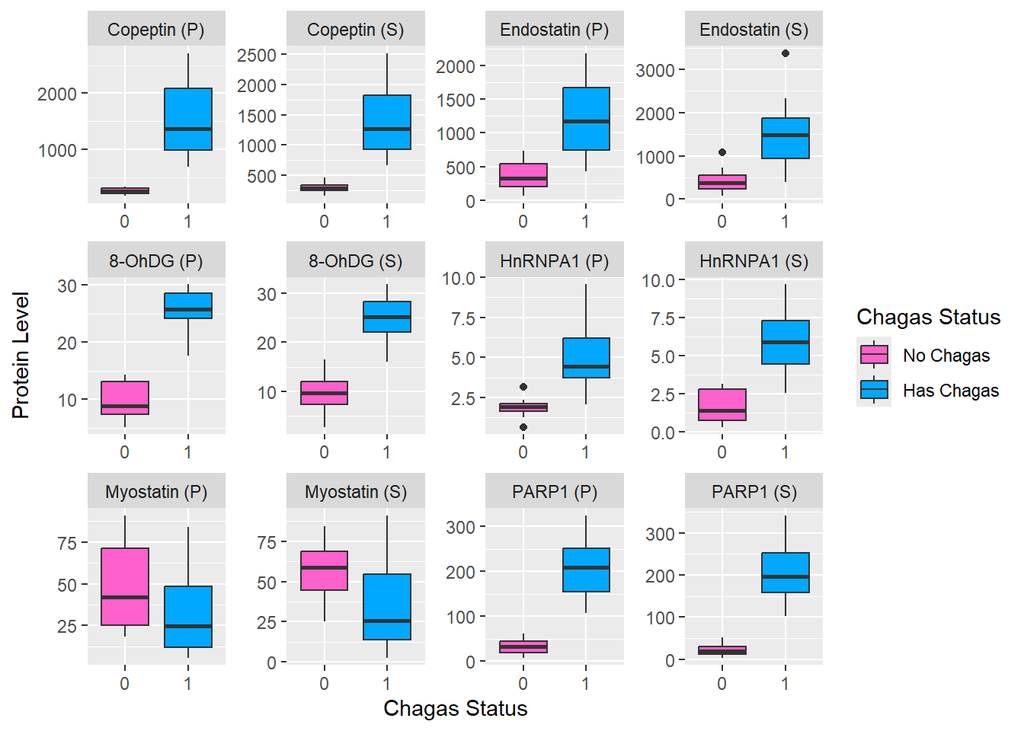

```r
# Create a list marker_labels full of each biomarker
marker_labels <- c(
  "Copeptin_Serum" = "Copeptin (S)",
  "Copeptin_Plasma" = "Copeptin (P)",
  "HnRNPA1_Serum" = "HnRNPA1 (S)",
  "HnRNPA1_Plasma" = "HnRNPA1 (P)",
  "Endostatin_Serum" = "Endostatin (S)",
  "Endostatin_Plasma" = "Endostatin (P)",
  "etOhDG_Serum" = "8-OhDG (S)",
  "etOhDG_Plasma" = "8-OhDG (P)",
  "Myostatin_Serum" = "Myostatin (S)",
  "Myostatin_Plasma" = "Myostatin (P)",
  "PARP1_Serum" = "PARP1 (S)",
  "PARP1_Plasma" = "PARP1 (P)"
)

#Chagas/ No Chagas boxplot
df_long <- data %>%
  pivot_longer(cols = ends_with("_Serum") | ends_with("_Plasma"),
               names_to = "marker",
               values_to = "value")

chag_labels <- c("0" = "No Chagas", "1" = "Has Chagas")

ggplot(data = df_long,
       aes(x = factor(chag), y = value, fill = factor(chag))) +
  geom_boxplot() +
  facet_wrap(~ marker,
             scales = "free",
             labeller = labeller(marker = marker_labels)) +
  scale_fill_manual(
    name = "Chagas Status",
    values = c("0" = "#FF61CC", "1" = "#00A9FF"),
    labels = chag_labels
  ) +
  labs(
    x = "Chagas Status",
    y = "Protein Level",
    fill = "Symptom Status"
  )
```

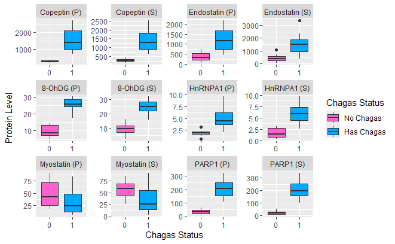

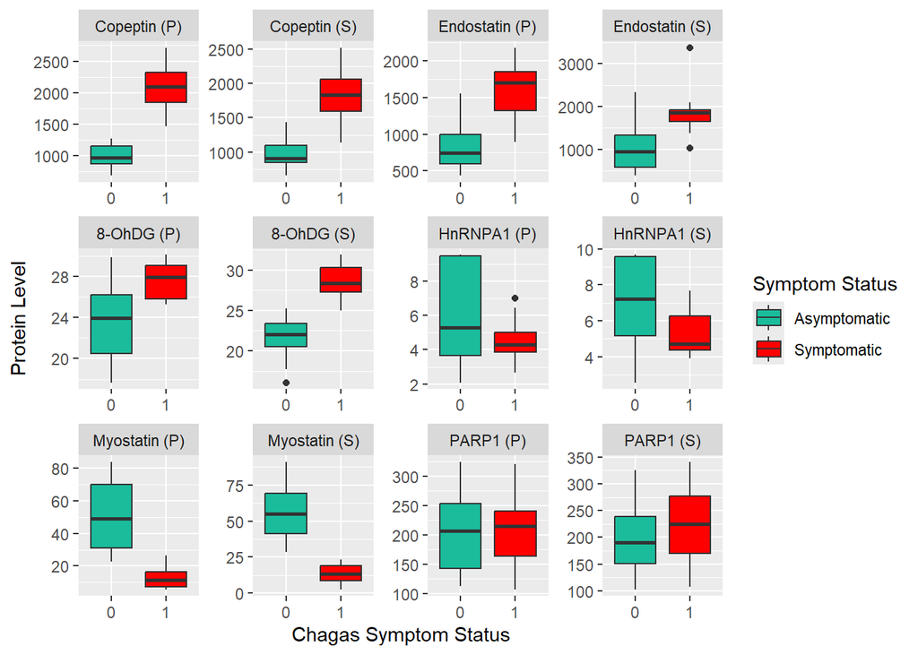

```r
#Sym/Asym boxplot
df_long2 <- data %>%
  pivot_longer(cols = ends_with("_Serum") | ends_with("_Plasma"),
               names_to = "marker",
               values_to = "value") %>%
  filter(sym == 0 | sym == 1)

sym_labels <- c("0" = "Asymptomatic", "1" = "Symptomatic")

ggplot(df_long2,
       aes(x = factor(sym), y = value, fill = factor(sym))) +
  geom_boxplot() +
  facet_wrap(~ marker,
             scales = "free",
             labeller = labeller(marker = marker_labels)) +
  scale_fill_manual(
    name = "Symptom Status",
    values = c("0" = "#1ABC9C", "1" = "red"),
    labels = sym_labels
  ) +
  labs(
    x = "Chagas Symptom Status",
    y = "Protein Level",
    fill = "Symptom Status"
  )
```

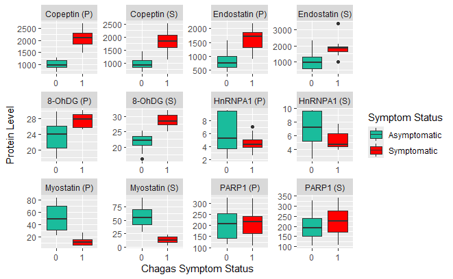

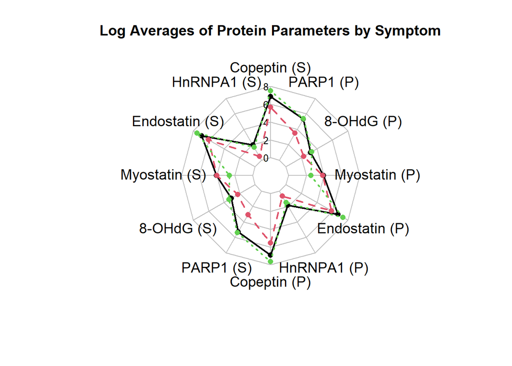

```r
#Group averages
avg_data <- data %>%
  group_by(Symptom) %>%
  summarise(across(matches("(_Serum|_Plasma)$"), mean, na.rm = TRUE)) %>%
  as.data.frame()
log_data <- avg_data %>%
  mutate(across(where(is.numeric), log))

# Set rownames from Symptom and remove that column
rownames(log_data) <- log_data$Symptom
log_data$Symptom <- NULL

# Set min and max values explicitly
min_val <- 0  # your observed raw minimum
max_val <- 8  # your observed raw maximum

custom_labels <- c("Copeptin (S)", "HnRNPA1 (S)", "Endostatin (S)", "Myostatin (S)",
                   "8-OHdG (S)", "PARP1 (S)", "Copeptin (P)", "HnRNPA1 (P)", "Endostatin (P)", "Myostatin (P)",
                   "8-OHdG (P)", "PARP1 (P)")

# Create df with required min and max rows
df_radar <- log_data
colnames(df_radar) <- custom_labels
df_radar <- rbind(rep(max_val, ncol(df_radar)),
                  rep(min_val, ncol(df_radar)),
                  df_radar)

# Define your custom sizes
axis_label_size <- 0.8     # Size of the axis label text
variable_label_size <- 1.2 # Size of the variable labels (vlcex)
title_size <- 1.5          # Size of the title

# Plot the radar chart
radarchart(df_radar,
           axistype = 1,
           caxislabels = round(seq(min_val, max_val, length.out = 5), 2),
           plwd = 2,
           cglcol = "grey",
           cglty = 1,
           axislabcol = "black",
           calcex = axis_label_size,  # axis label size
           vlcex = variable_label_size,  # variable name size
           title = "Log Averages of Protein Parameters by Symptom")
```

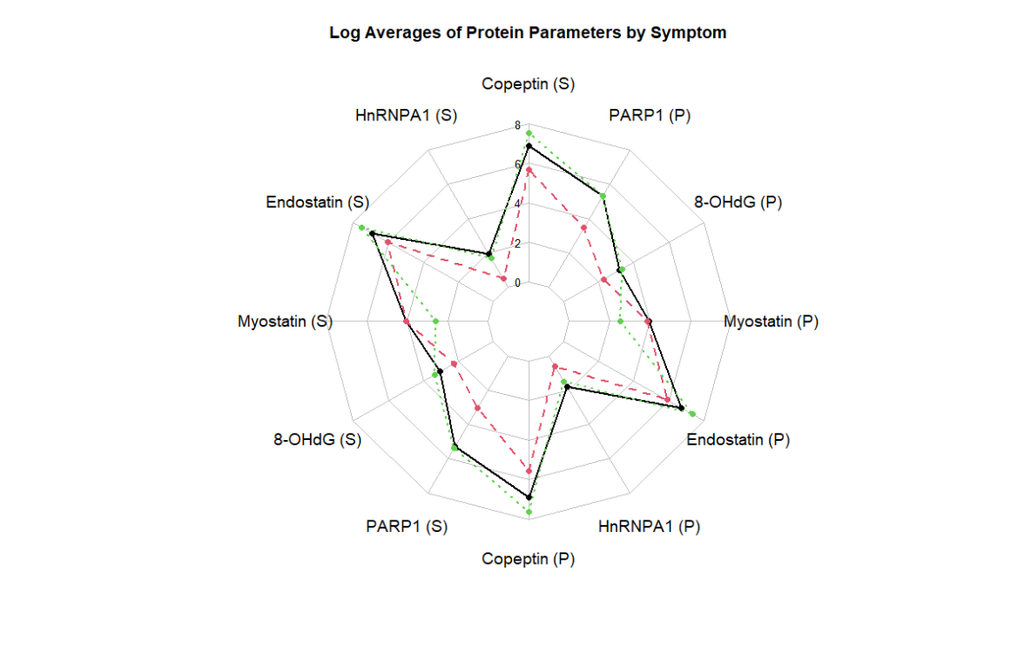

# Analysis

## Perform Logistic Regression to see if each Protein Parameter can classify whether a patient has or does not have Chagas Disease.

```r
list_roc_log_chag <- list()
list_cve_log_chag <- list()

protein_list <- c("Copeptin", "HnRNPA1", "Endostatin",
                  "Myostatin", "etOhDG", "PARP1")
sample_types <- c("Serum", "Plasma")


for (protein_name in protein_list) {
  for (sample_type in sample_types) {
    var_name <- paste0(protein_name, "_", sample_type)

    # Logistic regression
    formula <- as.formula(paste("chag ~", var_name))
    log.reg <- glm(formula, data = data, family = "binomial")
    print(summary(log.reg))

    # Odds ratios and confidence intervals
    cat("\nOdds Ratios:\n")
    #print(exp(coef(log.reg)))

    cat("\n95% CI for Odds Ratios:\n")
    print(exp(confint(log.reg)))

    # Predict probabilities
    pred.prob <- predict(log.reg, type = "response")

    # ROC and AUC
    roc_log <- roc(data$chag, pred.prob)
    roc_plot <- ggroc(roc_log) +
                ggtitle(paste(var_name, "ROC")) +
                theme_minimal(base_size = 9)
    list_roc_log_chag[[var_name]] <- roc_plot

     # CV error as ggplot
    set.seed(67)
    x <- as.matrix(cbind(var = data[[var_name]], dummy = rnorm(nrow(data), 0, 1e-6)))
    y <- as.factor(data$chag)
    cvfit <- cv.glmnet(x, y, family = "binomial", alpha = 0)

    cv_df <- data.frame(lambda = log(cvfit$lambda), cvm = cvfit$cvm, cvsd = cvfit$cvsd)

    cve_plot <- ggplot(cv_df, aes(x = lambda, y = cvm)) +
  geom_line(color = "blue") +
  geom_ribbon(aes(ymin = cvm - cvsd, ymax = cvm + cvsd), alpha = 0.2, fill = "blue") +
  geom_vline(xintercept = log(cvfit$lambda.min), linetype = "dashed", color = "red") +
  labs(title = paste(var_name, "CVE"), x = "log(Lambda)", y = "Mean CV Error") +
  theme_minimal(base_size = 8)

    list_cve_log_chag[[var_name]] <- cve_plot
  }
}
```

```
Call:
glm(formula = formula, family = "binomial", data = data)

Coefficients:
                 Estimate Std. Error z value Pr(>|z|)
(Intercept)     -113.3692 62115.7244  -0.002    0.999
Copeptin_Serum     0.2027   108.4756   0.002    0.999

(Dispersion parameter for binomial family taken to be 1)

    Null deviance: 5.0255e+01  on 41  degrees of freedom
Residual deviance: 6.2589e-09  on 40  degrees of freedom
AIC: 4

Number of Fisher Scoring iterations: 25


Odds Ratios:

95% CI for Odds Ratios:
```

```
                      2.5 %       97.5 %
(Intercept)    0.000000e+00          Inf
Copeptin_Serum 1.264114e-05 4.053237e+28
```

```
Call:
glm(formula = formula, family = "binomial", data = data)

Coefficients:
                  Estimate Std. Error z value Pr(>|z|)
(Intercept)       -62.4491 46946.0533  -0.001    0.999
Copeptin_Plasma     0.1215    83.3335   0.001    0.999

(Dispersion parameter for binomial family taken to be 1)

    Null deviance: 5.0255e+01  on 41  degrees of freedom
Residual deviance: 3.5320e-09  on 40  degrees of freedom
AIC: 4

Number of Fisher Scoring iterations: 25


Odds Ratios:

95% CI for Odds Ratios:
```

```
                       2.5 %       97.5 %
(Intercept)     0.0000000000          Inf
Copeptin_Plasma 0.0001668182 9.169398e+21
```

```
Call:
glm(formula = formula, family = "binomial", data = data)

Coefficients:
              Estimate Std. Error z value Pr(>|z|)
(Intercept)    -11.020      5.416  -2.035   0.0419 *
HnRNPA1_Serum    3.501      1.704   2.054   0.0399 *
---
Signif. codes:  0 '***' 0.001 '**' 0.01 '*' 0.05 '.' 0.1 ' ' 1

(Dispersion parameter for binomial family taken to be 1)

    Null deviance: 50.2546  on 41  degrees of freedom
Residual deviance:  8.8845  on 40  degrees of freedom
AIC: 12.884

Number of Fisher Scoring iterations: 9


Odds Ratios:

95% CI for Odds Ratios:
```

```
                     2.5 %       97.5 %
(Intercept)   6.417008e-13 1.710337e-02
HnRNPA1_Serum 4.059219e+00 8.362932e+03
```

```
Call:
glm(formula = formula, family = "binomial", data = data)

Coefficients:
               Estimate Std. Error z value Pr(>|z|)
(Intercept)      -9.005      3.218  -2.798  0.00513 **
HnRNPA1_Plasma    3.425      1.218   2.813  0.00490 **
---
Signif. codes:  0 '***' 0.001 '**' 0.01 '*' 0.05 '.' 0.1 ' ' 1

(Dispersion parameter for binomial family taken to be 1)

    Null deviance: 50.255  on 41  degrees of freedom
Residual deviance: 12.720  on 40  degrees of freedom
AIC: 16.72

Number of Fisher Scoring iterations: 8


Odds Ratios:

95% CI for Odds Ratios:
```

```
                     2.5 %       97.5 %
(Intercept)    2.36964e-08   0.01562776
HnRNPA1_Plasma 5.18124e+00 846.58906731
```

```
Call:
glm(formula = formula, family = "binomial", data = data)

Coefficients:
                  Estimate Std. Error z value Pr(>|z|)
(Intercept)      -2.765131   1.123160  -2.462  0.01382 *
Endostatin_Serum  0.004780   0.001717   2.783  0.00539 **
---
Signif. codes:  0 '***' 0.001 '**' 0.01 '*' 0.05 '.' 0.1 ' ' 1

(Dispersion parameter for binomial family taken to be 1)

    Null deviance: 50.255  on 41  degrees of freedom
Residual deviance: 25.669  on 40  degrees of freedom
AIC: 29.669

Number of Fisher Scoring iterations: 7


Odds Ratios:

95% CI for Odds Ratios:
```

```
                       2.5 %    97.5 %
(Intercept)      0.004200797 0.4089257
Endostatin_Serum 1.002211781 1.0092630
```

```
Call:
glm(formula = formula, family = "binomial", data = data)

Coefficients:
                   Estimate Std. Error z value Pr(>|z|)
(Intercept)       -4.645563   1.887426  -2.461  0.01384 *
Endostatin_Plasma  0.008729   0.003282   2.660  0.00782 **
---
Signif. codes:  0 '***' 0.001 '**' 0.01 '*' 0.05 '.' 0.1 ' ' 1

(Dispersion parameter for binomial family taken to be 1)

    Null deviance: 50.255  on 41  degrees of freedom
Residual deviance: 20.871  on 40  degrees of freedom
AIC: 24.871

Number of Fisher Scoring iterations: 7


Odds Ratios:

95% CI for Odds Ratios:
```

```
                         2.5 %    97.5 %
(Intercept)       7.697307e-05 0.1728679
Endostatin_Plasma 1.003883e+00 1.0173766
```

```
Call:
glm(formula = formula, family = "binomial", data = data)

Coefficients:
                Estimate Std. Error z value Pr(>|z|)
(Intercept)      2.54394    0.86577   2.938   0.0033 **
Myostatin_Serum -0.03516    0.01552  -2.266   0.0235 *
---
Signif. codes:  0 '***' 0.001 '**' 0.01 '*' 0.05 '.' 0.1 ' ' 1

(Dispersion parameter for binomial family taken to be 1)

    Null deviance: 50.255  on 41  degrees of freedom
Residual deviance: 44.230  on 40  degrees of freedom
AIC: 48.23

Number of Fisher Scoring iterations: 4


Odds Ratios:

95% CI for Odds Ratios:
```

```
                    2.5 %     97.5 %
(Intercept)     2.8130386 91.1289434
Myostatin_Serum 0.9333684  0.9932541
```

```
Call:
glm(formula = formula, family = "binomial", data = data)

Coefficients:
                 Estimate Std. Error z value Pr(>|z|)
(Intercept)       1.83328    0.66632   2.751  0.00593 **
Myostatin_Plasma -0.02326    0.01341  -1.735  0.08282 .
---
Signif. codes:  0 '***' 0.001 '**' 0.01 '*' 0.05 '.' 0.1 ' ' 1

(Dispersion parameter for binomial family taken to be 1)

    Null deviance: 50.255  on 41  degrees of freedom
Residual deviance: 47.126  on 40  degrees of freedom
AIC: 51.126

Number of Fisher Scoring iterations: 4


Odds Ratios:

95% CI for Odds Ratios:
```

```
                     2.5 %   97.5 %
(Intercept)      1.8588934 26.48646
Myostatin_Plasma 0.9502489  1.00251
```

```
Call:
glm(formula = formula, family = "binomial", data = data)

Coefficients:
             Estimate Std. Error z value Pr(>|z|)
(Intercept)   -24.675     21.291  -1.159    0.246
etOhDG_Serum    1.525      1.289   1.183    0.237

(Dispersion parameter for binomial family taken to be 1)

    Null deviance: 50.2546  on 41  degrees of freedom
Residual deviance:  3.8601  on 40  degrees of freedom
AIC: 7.8601

Number of Fisher Scoring iterations: 10


Odds Ratios:

95% CI for Odds Ratios:
```

```
                2.5 %       97.5 %
(Intercept)        NA 0.0004810767
etOhDG_Serum 1.653814           NA
```

```
Call:
glm(formula = formula, family = "binomial", data = data)

Coefficients:
               Estimate Std. Error z value Pr(>|z|)
(Intercept)     -197.36  144936.68  -0.001    0.999
etOhDG_Plasma     12.36    8947.05   0.001    0.999

(Dispersion parameter for binomial family taken to be 1)

    Null deviance: 5.0255e+01  on 41  degrees of freedom
Residual deviance: 3.2259e-09  on 40  degrees of freedom
AIC: 4

Number of Fisher Scoring iterations: 25


Odds Ratios:

95% CI for Odds Ratios:
```

```
              2.5 % 97.5 %
(Intercept)       0    Inf
etOhDG_Plasma     0    Inf
```

```
Call:
glm(formula = formula, family = "binomial", data = data)

Coefficients:
              Estimate Std. Error z value Pr(>|z|)
(Intercept)   -65.0447 51893.7269  -0.001    0.999
PARP1_Serum     0.8401   624.2661   0.001    0.999

(Dispersion parameter for binomial family taken to be 1)

    Null deviance: 5.0255e+01  on 41  degrees of freedom
Residual deviance: 3.0211e-09  on 40  degrees of freedom
AIC: 4

Number of Fisher Scoring iterations: 25


Odds Ratios:

95% CI for Odds Ratios:
```

```
                   2.5 %        97.5 %
(Intercept) 0.000000e+00           Inf
PARP1_Serum 4.673647e-29 3.113944e+164
```

```
Call:
glm(formula = formula, family = "binomial", data = data)

Coefficients:
               Estimate Std. Error z value Pr(>|z|)
(Intercept)    -78.2044 60438.9851  -0.001    0.999
PARP1_Plasma     0.9282   677.4301   0.001    0.999

(Dispersion parameter for binomial family taken to be 1)

    Null deviance: 5.0255e+01  on 41  degrees of freedom
Residual deviance: 3.1648e-09  on 40  degrees of freedom
AIC: 4

Number of Fisher Scoring iterations: 25


Odds Ratios:

95% CI for Odds Ratios:
```

```
                   2.5 %       97.5 %
(Intercept)  0.00000e+00          Inf
PARP1_Plasma 1.83727e-31 3.22963e+178
```

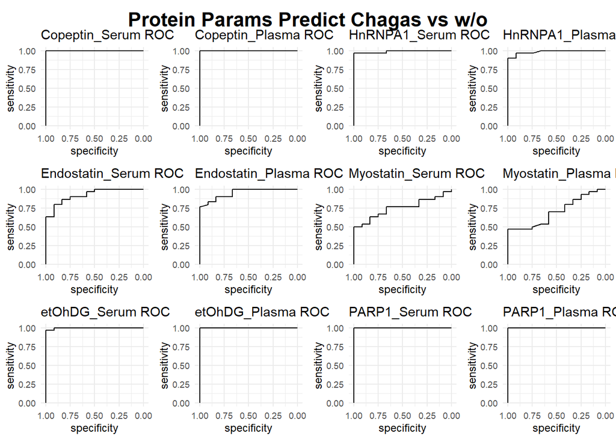

```r
grid.arrange(grobs = list_roc_log_chag,
               top = textGrob("Protein Params Predict Chagas vs w/o",
                              just = "top",
                              gp = gpar(fontsize = 16, fontface = "bold")),
               ncol = 4)
```

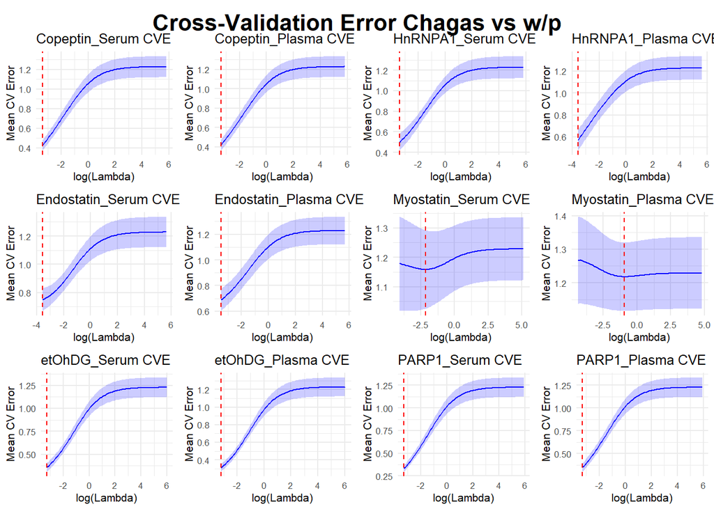

```r
grid.arrange(grobs = list_cve_log_chag,
               top = textGrob("Cross-Validation Error Chagas vs w/p",
                              just = "top",
                              gp = gpar(fontsize = 16, fontface = "bold")),
               ncol = 4)
```

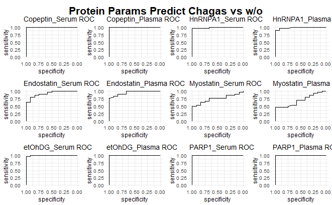

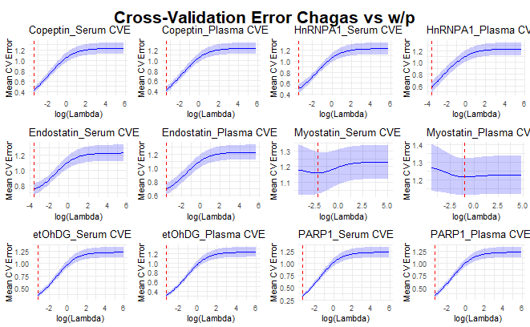

## Perform Logistic Regression to see if each Protein Parameter can classify whether a Chagas Patient is Symptomatic or Asymptomatic.

```r
list_roc_log_asymsym <- list()
list_cve_log_asymsym <- list()

protein_list <- c("Copeptin", "HnRNPA1", "Endostatin",
                  "Myostatin", "etOhDG", "PARP1")
sample_types <- c("Serum", "Plasma")

# Remove rows with NA in outcome or predictor
clean_data <- data[!is.na(data[[var_name]]) & !is.na(data$sym), ]

for (protein_name in protein_list) {
  for (sample_type in sample_types) {
    var_name <- paste0(protein_name, "_", sample_type)

    # Logistic regression
    formula <- as.formula(paste("sym ~", var_name))
    log.reg <- glm(formula, data = clean_data, family = "binomial")
    print(summary(log.reg))

    # Odds ratios and confidence intervals
    cat("\nOdds Ratios:\n")
    print(exp(coef(log.reg)))

    cat("\n95% CI for Odds Ratios:\n")
    print(exp(confint(log.reg)))

    # Predict probabilities
    pred.prob <- predict(log.reg, type = "response")

    # ROC and AUC
    roc_log <- roc(clean_data$sym, pred.prob)
    roc_plot <- ggroc(roc_log) +
                ggtitle(paste(var_name, "ROC")) +
                theme_minimal(base_size = 9)
    list_roc_log_asymsym[[var_name]] <- roc_plot

    # CV error as ggplot
    set.seed(67)
    x <- as.matrix(cbind(var = clean_data[[var_name]], dummy = rnorm(nrow(clean_data), 0, 1e-6)))
    y <- as.factor(clean_data$sym)
    cvfit <- cv.glmnet(x, y, family = "binomial", alpha = 0)

    cv_df <- data.frame(lambda = log(cvfit$lambda), cvm = cvfit$cvm, cvsd = cvfit$cvsd)

    cve_plot <- ggplot(cv_df, aes(x = lambda, y = cvm)) +
  geom_line(color = "blue") +
  geom_ribbon(aes(ymin = cvm - cvsd, ymax = cvm + cvsd), alpha = 0.2, fill = "blue") +
  geom_vline(xintercept = log(cvfit$lambda.min), linetype = "dashed", color = "red") +
  labs(title = paste(var_name, "CVE"), x = "log(Lambda)", y = "Mean CV Error") +
  theme_minimal(base_size = 8)

  list_cve_log_asymsym[[var_name]] <- cve_plot
  }
}
```

```
Call:
glm(formula = formula, family = "binomial", data = clean_data)

Coefficients:
                 Estimate Std. Error z value Pr(>|z|)
(Intercept)    -13.455844   5.369563  -2.506   0.0122 *
Copeptin_Serum   0.010391   0.004229   2.457   0.0140 *
---
Signif. codes:  0 '***' 0.001 '**' 0.01 '*' 0.05 '.' 0.1 ' ' 1

(Dispersion parameter for binomial family taken to be 1)

    Null deviance: 41.5888  on 29  degrees of freedom
Residual deviance:  9.8578  on 28  degrees of freedom
AIC: 13.858

Number of Fisher Scoring iterations: 7


Odds Ratios:
   (Intercept) Copeptin_Serum
  1.432852e-06   1.010445e+00

95% CI for Odds Ratios:
```

```
                      2.5 %     97.5 %
(Intercept)    4.569916e-13 0.00248031
Copeptin_Serum 1.004553e+00 1.02221505
```

```
Call:
glm(formula = formula, family = "binomial", data = clean_data)

Coefficients:
                  Estimate Std. Error z value Pr(>|z|)
(Intercept)     -2.964e+02  2.242e+05  -0.001    0.999
Copeptin_Plasma  2.161e-01  1.637e+02   0.001    0.999

(Dispersion parameter for binomial family taken to be 1)

    Null deviance: 4.1589e+01  on 29  degrees of freedom
Residual deviance: 2.8043e-09  on 28  degrees of freedom
AIC: 4

Number of Fisher Scoring iterations: 25


Odds Ratios:
    (Intercept) Copeptin_Plasma
  1.968299e-129    1.241234e+00

95% CI for Odds Ratios:
```

```
                       2.5 %       97.5 %
(Intercept)     0.000000e+00          Inf
Copeptin_Plasma 8.756756e+50 3.907587e+74
```

```
Call:
glm(formula = formula, family = "binomial", data = clean_data)

Coefficients:
              Estimate Std. Error z value Pr(>|z|)
(Intercept)     2.5846     1.3263   1.949   0.0513 .
HnRNPA1_Serum  -0.4217     0.2098  -2.010   0.0444 *
---
Signif. codes:  0 '***' 0.001 '**' 0.01 '*' 0.05 '.' 0.1 ' ' 1

(Dispersion parameter for binomial family taken to be 1)

    Null deviance: 41.589  on 29  degrees of freedom
Residual deviance: 36.739  on 28  degrees of freedom
AIC: 40.739

Number of Fisher Scoring iterations: 4


Odds Ratios:
  (Intercept) HnRNPA1_Serum
   13.2586280     0.6559135

95% CI for Odds Ratios:
```

```
                 2.5 %      97.5 %
(Intercept)   1.169308 239.5225380
HnRNPA1_Serum 0.410906   0.9571554
```

```
Call:
glm(formula = formula, family = "binomial", data = clean_data)

Coefficients:
               Estimate Std. Error z value Pr(>|z|)
(Intercept)      1.7928     1.0335   1.735   0.0828 .
HnRNPA1_Plasma  -0.3425     0.1893  -1.809   0.0704 .
---
Signif. codes:  0 '***' 0.001 '**' 0.01 '*' 0.05 '.' 0.1 ' ' 1

(Dispersion parameter for binomial family taken to be 1)

    Null deviance: 41.589  on 29  degrees of freedom
Residual deviance: 37.638  on 28  degrees of freedom
AIC: 41.638

Number of Fisher Scoring iterations: 4


Odds Ratios:
   (Intercept) HnRNPA1_Plasma
     6.0064831      0.7099747

95% CI for Odds Ratios:
```

```
                   2.5 %     97.5 %
(Intercept)    0.8857925 56.5507267
HnRNPA1_Plasma 0.4590973  0.9954841
```

```
Call:
glm(formula = formula, family = "binomial", data = clean_data)

Coefficients:
                 Estimate Std. Error z value Pr(>|z|)
(Intercept)      -4.94727    1.84420  -2.683  0.00730 **
Endostatin_Serum  0.00347    0.00121   2.868  0.00413 **
---
Signif. codes:  0 '***' 0.001 '**' 0.01 '*' 0.05 '.' 0.1 ' ' 1

(Dispersion parameter for binomial family taken to be 1)

    Null deviance: 41.589  on 29  degrees of freedom
Residual deviance: 25.480  on 28  degrees of freedom
AIC: 29.48

Number of Fisher Scoring iterations: 5


Odds Ratios:
     (Intercept) Endostatin_Serum
     0.007102759      1.003476209

95% CI for Odds Ratios:
```

```
                        2.5 %    97.5 %
(Intercept)      7.455464e-05 0.1378635
Endostatin_Serum 1.001496e+00 1.0064317
```

```
Call:
glm(formula = formula, family = "binomial", data = clean_data)

Coefficients:
                   Estimate Std. Error z value Pr(>|z|)
(Intercept)       -5.771626   1.986148  -2.906  0.00366 **
Endostatin_Plasma  0.004854   0.001627   2.984  0.00285 **
---
Signif. codes:  0 '***' 0.001 '**' 0.01 '*' 0.05 '.' 0.1 ' ' 1

(Dispersion parameter for binomial family taken to be 1)

    Null deviance: 41.589  on 29  degrees of freedom
Residual deviance: 21.624  on 28  degrees of freedom
AIC: 25.624

Number of Fisher Scoring iterations: 5


Odds Ratios:
      (Intercept) Endostatin_Plasma
       0.00311469        1.00486537

95% CI for Odds Ratios:
```

```
                         2.5 %     97.5 %
(Intercept)       2.093541e-05 0.07440507
Endostatin_Plasma 1.002278e+00 1.00899443
```

```
Call:
glm(formula = formula, family = "binomial", data = clean_data)

Coefficients:
                  Estimate Std. Error z value Pr(>|z|)
(Intercept)        199.402 108478.494   0.002    0.999
Myostatin_Serum     -7.736   4220.767  -0.002    0.999

(Dispersion parameter for binomial family taken to be 1)

    Null deviance: 4.1589e+01  on 29  degrees of freedom
Residual deviance: 6.0262e-09  on 28  degrees of freedom
AIC: 4

Number of Fisher Scoring iterations: 25


Odds Ratios:
    (Intercept) Myostatin_Serum
   3.973201e+86    4.368689e-04

95% CI for Odds Ratios:
```

```
                2.5 %        97.5 %
(Intercept)         0           Inf
Myostatin_Serum     0 6.898864e-121
```

```
Call:
glm(formula = formula, family = "binomial", data = clean_data)

Coefficients:
                 Estimate Std. Error z value Pr(>|z|)
(Intercept)       11.0947     5.5424   2.002   0.0453 *
Myostatin_Plasma  -0.4574     0.2228  -2.053   0.0401 *
---
Signif. codes:  0 '***' 0.001 '**' 0.01 '*' 0.05 '.' 0.1 ' ' 1

(Dispersion parameter for binomial family taken to be 1)

    Null deviance: 41.5888  on 29  degrees of freedom
Residual deviance:  5.9228  on 28  degrees of freedom
AIC: 9.9228

Number of Fisher Scoring iterations: 9


Odds Ratios:
     (Intercept) Myostatin_Plasma
    6.581930e+04     6.329227e-01

95% CI for Odds Ratios:
```

```
                      2.5 %       97.5 %
(Intercept)      71.4861844 7.555663e+12
Myostatin_Plasma  0.3045928 8.394907e-01
```

```
Call:
glm(formula = formula, family = "binomial", data = clean_data)

Coefficients:
             Estimate Std. Error z value Pr(>|z|)
(Intercept)   -92.877     71.857  -1.293    0.196
etOhDG_Serum    3.678      2.848   1.291    0.197

(Dispersion parameter for binomial family taken to be 1)

    Null deviance: 41.5888  on 29  degrees of freedom
Residual deviance:  5.2279  on 28  degrees of freedom
AIC: 9.2279

Number of Fisher Scoring iterations: 10


Odds Ratios:
 (Intercept) etOhDG_Serum
4.614953e-41 3.956285e+01

95% CI for Odds Ratios:
```

```
                     2.5 %       97.5 %
(Intercept)  1.311675e-159 6.100359e-11
etOhDG_Serum  2.538397e+00 2.034490e+06
```

```
Call:
glm(formula = formula, family = "binomial", data = clean_data)

Coefficients:
              Estimate Std. Error z value Pr(>|z|)
(Intercept)   -13.1940     5.3001  -2.489   0.0128 *
etOhDG_Plasma   0.5066     0.2004   2.528   0.0115 *
---
Signif. codes:  0 '***' 0.001 '**' 0.01 '*' 0.05 '.' 0.1 ' ' 1

(Dispersion parameter for binomial family taken to be 1)

    Null deviance: 41.589  on 29  degrees of freedom
Residual deviance: 29.927  on 28  degrees of freedom
AIC: 33.927

Number of Fisher Scoring iterations: 5


Odds Ratios:
  (Intercept) etOhDG_Plasma
 1.861760e-06  1.659701e+00

95% CI for Odds Ratios:
```

```
                     2.5 %      97.5 %
(Intercept)   5.719765e-12 0.009414068
etOhDG_Plasma 1.200176e+00 2.683447211
```

```
Call:
glm(formula = formula, family = "binomial", data = clean_data)

Coefficients:
             Estimate Std. Error z value Pr(>|z|)
(Intercept) -1.122391   1.206856  -0.930    0.352
PARP1_Serum  0.005372   0.005504   0.976    0.329

(Dispersion parameter for binomial family taken to be 1)

    Null deviance: 41.589  on 29  degrees of freedom
Residual deviance: 40.604  on 28  degrees of freedom
AIC: 44.604

Number of Fisher Scoring iterations: 4


Odds Ratios:
(Intercept) PARP1_Serum
  0.3255007   1.0053867

95% CI for Odds Ratios:
```

```
                 2.5 %   97.5 %
(Intercept) 0.02646357 3.317171
PARP1_Serum 0.99483220 1.017008
```

```
Call:
glm(formula = formula, family = "binomial", data = clean_data)

Coefficients:
               Estimate Std. Error z value Pr(>|z|)
(Intercept)  -0.1921724  1.2497098  -0.154    0.878
PARP1_Plasma  0.0009268  0.0057639   0.161    0.872

(Dispersion parameter for binomial family taken to be 1)

    Null deviance: 41.589  on 29  degrees of freedom
Residual deviance: 41.563  on 28  degrees of freedom
AIC: 45.563

Number of Fisher Scoring iterations: 3


Odds Ratios:
 (Intercept) PARP1_Plasma
   0.8251646    1.0009272

95% CI for Odds Ratios:
```

```
                  2.5 %   97.5 %
(Intercept)  0.06654829 9.902223
PARP1_Plasma 0.98951575 1.012640
```

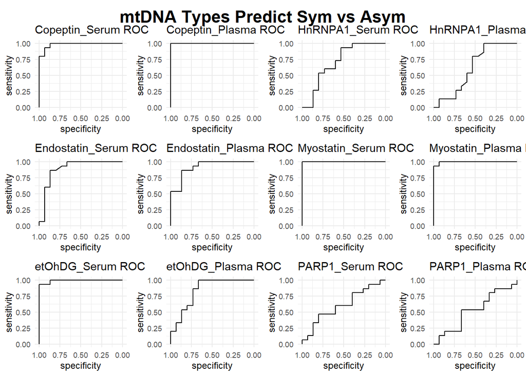

```r
grid.arrange(grobs = list_roc_log_asymsym,
               top = textGrob("mtDNA Types Predict Sym vs Asym",
                              just = "top",
                              gp = gpar(fontsize = 16, fontface = "bold")),
               ncol = 4)
```

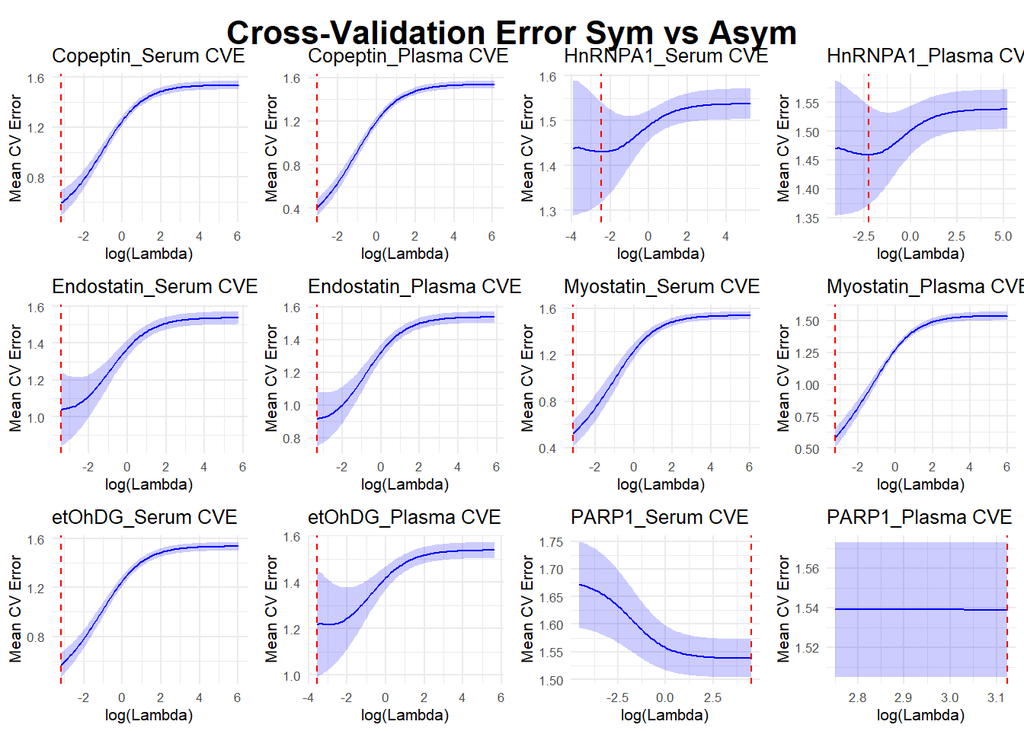

```r
grid.arrange(grobs = list_cve_log_asymsym,
               top = textGrob("Cross-Validation Error Sym vs Asym",
                              just = "top",
                              gp = gpar(fontsize = 16, fontface = "bold")),
               ncol = 4)
```

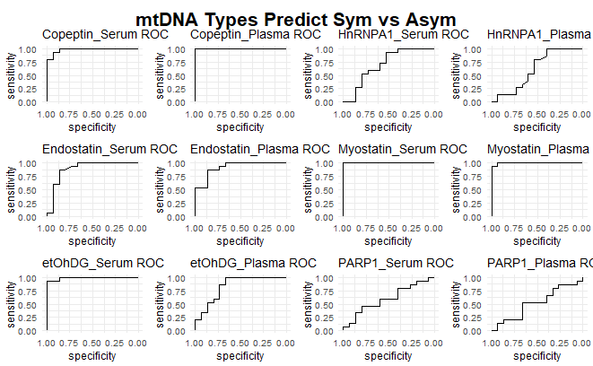

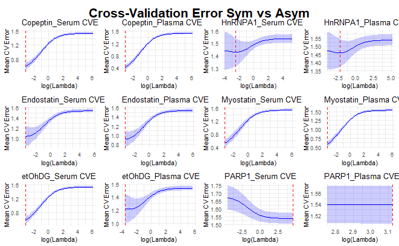

## Data Visualization - Graphing Results

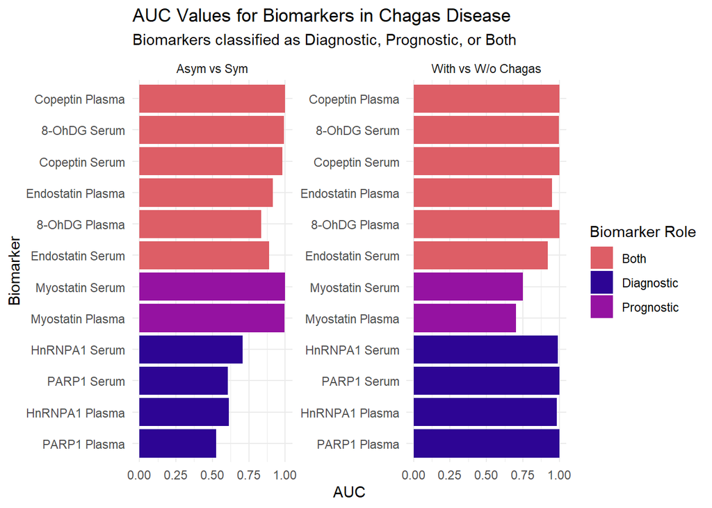

```r
#Create a tidy dataframe of AUC results
diagnosis_auc <- tribble(
  ~Biomarker, ~Sample, ~AUC,
  "Copeptin", "Serum", 1,
  "Copeptin", "Plasma", 1,
  "HnRNPA1", "Serum", 0.9888889,
  "HnRNPA1", "Plasma", 0.9847222,
  "Endostatin", "Serum", 0.9222222,
  "Endostatin", "Plasma", 0.9513889,
  "Myostatin", "Serum", 0.75,
  "Myostatin", "Plasma", 0.7013889,
  "8-OhDG", "Serum", 0.9972222,
  "8-OhDG", "Plasma", 1,
  "PARP1", "Serum", 1,
  "PARP1", "Plasma", 1
)

prognosis_auc <- tribble(
  ~Biomarker, ~Sample, ~AUC,
  "Copeptin", "Serum", 0.9822222,
  "Copeptin", "Plasma", 1,
  "HnRNPA1", "Serum", 0.7066667,
  "HnRNPA1", "Plasma", 0.6133333,
  "Endostatin", "Serum", 0.8911111,
  "Endostatin", "Plasma", 0.9155556,
  "Myostatin", "Serum", 1,
  "Myostatin", "Plasma", 0.9955556,
  "8-OhDG", "Serum", 0.9911111,
  "8-OhDG", "Plasma", 0.8355556,
  "PARP1", "Serum", 0.6044444,
  "PARP1", "Plasma", 0.5244444
)

#Categorize AUC levels
auc_category <- function(x) {
  case_when(
    x >= 0.9 ~ "Excellent (≥ 0.9)",
    x >= 0.8 ~ "Good (0.8–0.9)",
    TRUE ~ "Moderate/Low (< 0.8)"
  )
}

#Category columns
diagnosis_auc <- diagnosis_auc %>%
  mutate(Category = auc_category(AUC),
         Group = "With vs W/o Chagas")

prognosis_auc <- prognosis_auc %>%
  mutate(Category = auc_category(AUC),
         Group = "Asym vs Sym")

#Combine
combined_auc <- bind_rows(diagnosis_auc, prognosis_auc)

# Classification vector
classification_df <- tribble(
  ~Biomarker, ~Classification,
  "Copeptin", "Both",
  "HnRNPA1", "Diagnostic",
  "Endostatin", "Both",
  "Myostatin", "Prognostic",
  "8-OhDG", "Both",
  "PARP1", "Diagnostic"
)

# Merge classification into AUC data
combined_auc_labeled <- combined_auc %>%
  left_join(classification_df, by = "Biomarker")

# Plot with biomarker role
ggplot(combined_auc_labeled, aes(x = reorder(paste(Biomarker, Sample, sep = " "), AUC),
                                 y = AUC, fill = Classification)) +
  geom_col() +
  coord_flip() +
  facet_wrap(~Group, scales = "free_y") +
  scale_fill_manual(values = c("Diagnostic" = "#2d0594FF",
                               "Prognostic" = "#9512A1FF",
                               "Both" = "#DD5E66FF")) +
  labs(title = "AUC Values for Biomarkers in Chagas Disease",
       subtitle = "Biomarkers classified as Diagnostic, Prognostic, or Both",
       x = "Biomarker",
       y = "AUC",
       fill = "Biomarker Role") +
    theme_minimal()
```

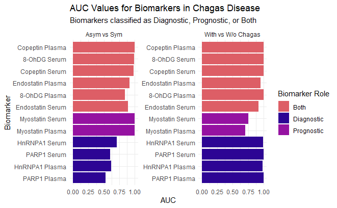

# Import Data

```r
mdata <- read_xlsx("~/R Notes/MitochondrialDNA.xlsx")

# "disease" column for asym,sym (1) and NHS (0)
mdata <- mdata %>%
  mutate(disease = case_when(
    Symptom == "NHS" ~ 0,
    Symptom == "Asymptomatic C" ~ 1,
    Symptom == "Symptomatic C" ~ 1
    )
  )

# "sym" column for asym (0) and sym (1)
mdata <- mdata %>%
  mutate(sym = case_when(
    Symptom == "Asymptomatic C" ~ 0,
    Symptom == "Symptomatic C" ~ 1
  ))

# These lists will be used for loops :D
list_DNA_Types <- c("mtND1", "mtND5", "mtATP6", "mtCOII", "mtCytB")
list_Group_Types <- c("NHS", "Asymptomatic C", "Symptomatic C")
```

## Perform Logistic Regression to see if each Mitochondrial DNA Type can classify whether a patient has or does not have Chagas Disease.

```r
# Empty lists to store ggplots
plot_list <- list()
cve_plot_list <- list()

for (DNA_Type in list_DNA_Types) {
  # --- ROC plots ---
  formula_text <- paste("disease ~", DNA_Type)
  mit_model <- glm(as.formula(formula_text), data = mdata, family = binomial)
  prob <- predict(mit_model, type = "response")
  roc_obj <- roc(mdata$disease, prob)

  roc_plot <- ggroc(roc_obj) +
    ggtitle(paste(DNA_Type, "ROC")) +
    theme_minimal()

  auc_value <- auc(roc_obj)
  print(paste0(DNA_Type, " AUC: ", auc_value))
  plot_list[[DNA_Type]] <- roc_plot

  # --- CV error plots ---
  set.seed(67)
  x <- as.matrix(cbind(
  var   = mdata[[DNA_Type]],
  dummy = rnorm(nrow(mdata), 0, 1e-6)  # tiny noise column
))
y <- as.factor(mdata$disease)

cvfit <- cv.glmnet(x, y, family = "binomial", alpha = 0)

  cv_df <- data.frame(
    lambda = log(cvfit$lambda),
    cvm    = cvfit$cvm,
    cvsd   = cvfit$cvsd
  )

  cve_plot <- ggplot(cv_df, aes(x = lambda, y = cvm)) +
    geom_line(color = "blue") +
    geom_ribbon(aes(ymin = cvm - cvsd, ymax = cvm + cvsd),
                alpha = 0.2, fill = "blue") +
    geom_vline(xintercept = log(cvfit$lambda.min),
               linetype = "dashed", color = "red") +
    labs(title = paste(DNA_Type, "CV Error"),
         x = "log(Lambda)", y = "Mean CV Error") +
    theme_minimal(base_size = 12)

  cve_plot_list[[DNA_Type]] <- cve_plot
}
```

```
[1] "mtND1 AUC: 0.836111111111111"
```

```
[1] "mtND5 AUC: 0.583333333333333"
```

```
[1] "mtATP6 AUC: 0.813888888888889"
```

```
[1] "mtCOII AUC: 0.441666666666667"
```

```
[1] "mtCytB AUC: 0.544444444444444"
```

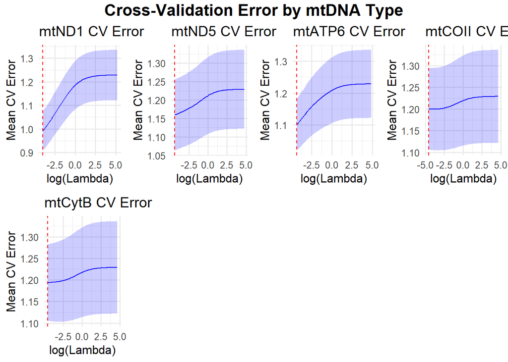

```r
# Arrange plots
grid.arrange(grobs = cve_plot_list,
             top = textGrob("Cross-Validation Error by mtDNA Type",
                            gp = gpar(fontsize = 16, fontface = "bold")),
             ncol = 4)
```

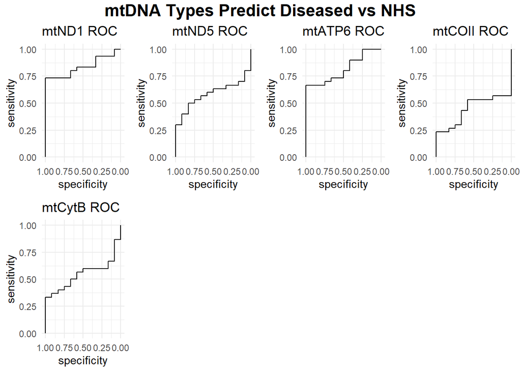

```r
grid.arrange(grobs = plot_list,
             top = textGrob("mtDNA Types Predict Diseased vs NHS",
                            gp = gpar(fontsize = 16, fontface = "bold")),
             ncol = 4)
```

### mtDNA Types Predicting Disased vs Control Logistic Model AUC Values:

### mtND1 AUC: 0.836111111111111 mtND5 AUC: 0.583333333333333 mtATP6 AUC: 0.813888888888889 mtCOII AUC: 0.441666666666667 mtCytB AUC: 0.544444444444444

[figure not shown]

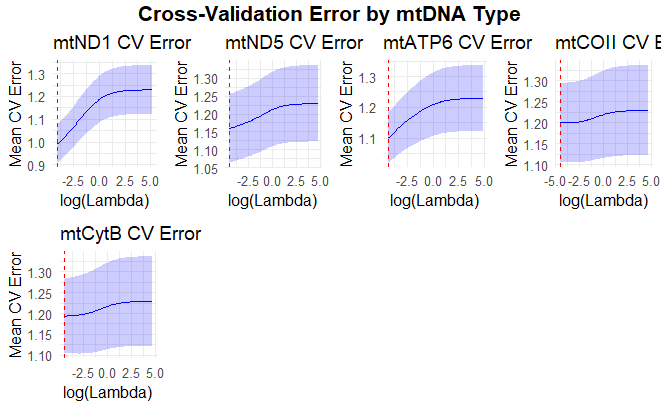

## Perform Logistic Regression to see if each Mitochondrial DNA Type can classify whether a patient is Symptomatic or Asymptomatic.

```r
# Empty lists to store ggplots
plot_list <- list()
cve_plot_list <- list()

# Remove rows with NAs in the 'sym' column
asmdata <- mdata %>%
  filter(!is.na(sym))

for (DNA_Type in list_DNA_Types) {
  # Design matrix (with intercept)
  x <- model.matrix(as.formula(paste("~", DNA_Type)), data = asmdata)
  y <- as.factor(asmdata$sym)

  # Cross-validated glmnet model
  cvfit <- cv.glmnet(x, y, family = "binomial", alpha = 0)

  # --- ROC plots (use cv.glmnet fit) ---
  prob <- predict(cvfit, newx = x, s = "lambda.min", type = "response")
  roc_obj <- roc(asmdata$sym, as.numeric(prob))

  roc_plot <- ggroc(roc_obj) +
    ggtitle(paste(DNA_Type, "ROC")) +
    theme_minimal()

  auc_value <- auc(roc_obj)
  print(paste0(DNA_Type, " AUC: ", auc_value))
  plot_list[[DNA_Type]] <- roc_plot

  # --- CV error plots ---
  set.seed(67)
  cv_df <- data.frame(
    lambda = log(cvfit$lambda),
    cvm    = cvfit$cvm,
    cvsd   = cvfit$cvsd
  )

  cve_plot <- ggplot(cv_df, aes(x = lambda, y = cvm)) +
    geom_line(color = "blue") +
    geom_ribbon(aes(ymin = cvm - cvsd, ymax = cvm + cvsd),
                alpha = 0.2, fill = "blue") +
    geom_vline(xintercept = log(cvfit$lambda.min),
               linetype = "dashed", color = "red") +
    labs(title = paste(DNA_Type, "CV Error"),
         x = "log(Lambda)", y = "Mean CV Error") +
    theme_minimal(base_size = 12)

  cve_plot_list[[DNA_Type]] <- cve_plot
}
```

```
[1] "mtND1 AUC: 0.991111111111111"
```

```
[1] "mtND5 AUC: 1"
```

```
[1] "mtATP6 AUC: 1"
```

```
[1] "mtCOII AUC: 0.924444444444445"
```

```
[1] "mtCytB AUC: 0.942222222222222"
```

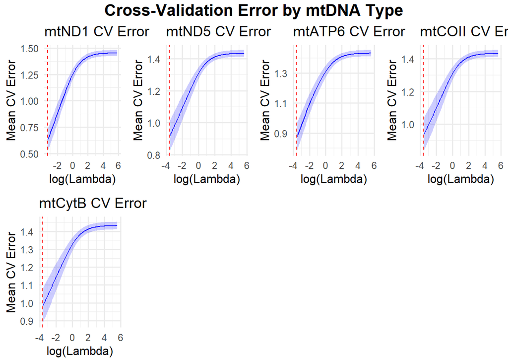

```r
# Arrange plots
grid.arrange(grobs = cve_plot_list,
             top = textGrob("Cross-Validation Error by mtDNA Type",
                            gp = gpar(fontsize = 16, fontface = "bold")),
             ncol = 4)
```

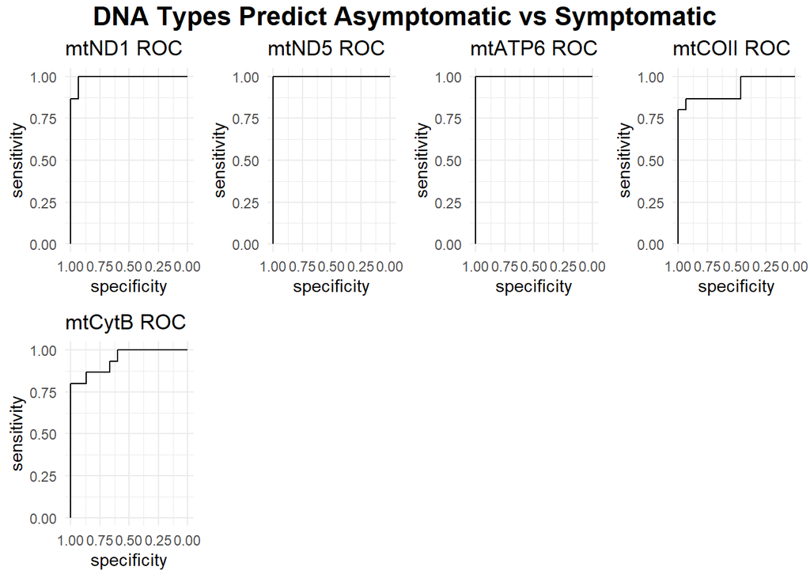

```r
grid.arrange(grobs = plot_list,
             top = textGrob("DNA Types Predict Asymptomatic vs Symptomatic",
                            gp = gpar(fontsize = 16, fontface = "bold")),
             ncol = 4)
```

### DNA Types Predicting Asymptomatic vs Symptomatic Logistic Model AUC Values:

### mtND1 AUC: 0.991111111111111 mtND5 AUC: 1 mtATP6 AUC: 1 mtCOII AUC: 0.924444444444445 mtCytB AUC: 0.942222222222222

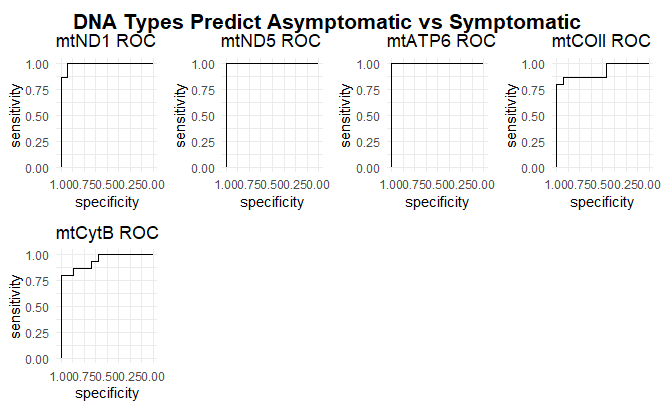

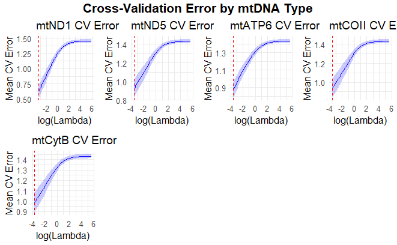

## Visualize Results

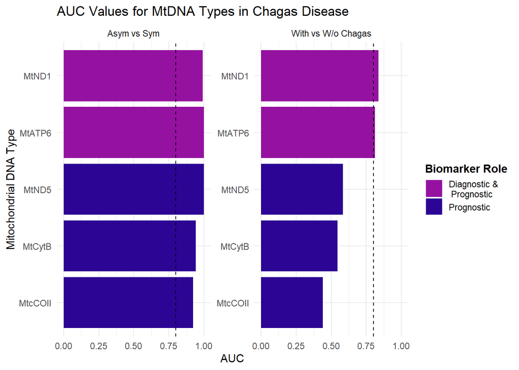

```r
# AUC dataframe
auc_mtdata <- data.frame(
  Gene = c("MtND1", "MtND5", "MtATP6", "MtcCOII", "MtCytB"),
  Control_vs_Disease = c(0.836, 0.583, 0.813, 0.441, 0.544),
  Sym_vs_Asym = c(0.991, 1, 1, 0.924, 0.942)
)

# Pivot to long format
data_long <- pivot_longer(auc_mtdata,
                          cols = -Gene,
                          names_to = "Comparison",
                          values_to = "AUC")

# Classify role
gene_classification <- auc_mtdata %>%
  mutate(
    Role = case_when(
      Control_vs_Disease >= 0.8 & Sym_vs_Asym >= 0.8 ~ "Diagnostic &\n Prognostic",
      Control_vs_Disease >= 0.8 ~ "Diagnostic",
      Sym_vs_Asym >= 0.8 ~ "Prognostic",
      TRUE ~ "Neither"
    )
  )

# Reshape for ggplot
data_long <- pivot_longer(gene_classification,
                          cols = c(Control_vs_Disease, Sym_vs_Asym),
                          names_to = "Comparison",
                          values_to = "AUC") %>%
  mutate(
    ComparisonLabel = case_when(
      Comparison == "Control_vs_Disease" ~ "With vs W/o Chagas",
      Comparison == "Sym_vs_Asym" ~ "Asym vs Sym"
    )
  )

# Base plot
plot_main <- ggplot(data_long, aes(x = AUC, y = reorder(Gene, AUC), fill = Role)) +
  geom_col() +
  facet_wrap(~ComparisonLabel, scales = "free_y") +
  geom_vline(xintercept = 0.8, linetype = "dashed", color = "black", linewidth = 0.5) +
  scale_fill_manual(
    values = c(
      # Pink = "#DD5E66",
      # Blue = "#2d0594",
      # Purple = "#9512A1",
      "Diagnostic &\n Prognostic" = "#9512A1",
      "Diagnostic" = "#DD5E66",
      "Prognostic" = "#2d0594",
      "Neither" = "gray70"
    )
  ) +
  labs(
    title = "AUC Values for MtDNA Types in Chagas Disease",
    x = "AUC", y = "Mitochondrial DNA Type"
  ) +
  theme_minimal() +
  theme(legend.title = element_text(face = "bold")) +
  labs(fill = "Biomarker Role")

plot(plot_main)
```

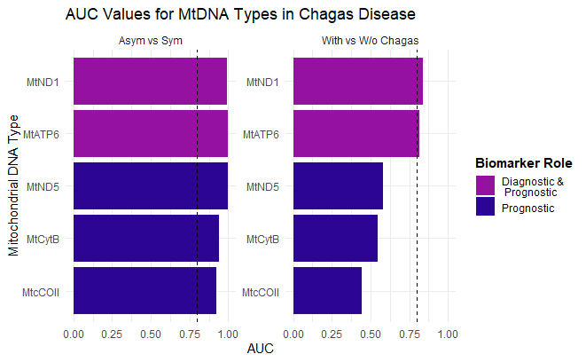